# Response of Basal Area Growth of Scots Pine to Thinning: A Longitudinal Analysis of Tree-Specific Series Using a Nonlinear Mixed-Effects Model | Forest Science | Oxford Academic

[figure not shown]

[figure not shown]

[figure not shown]

Volume 60

Issue 4

August 2014

### Article Contents

# The Response of Basal Area Growth of Scots Pine to Thinning: A Longitudinal Analysis of Tree-Specific Series Using a Nonlinear Mixed-Effects Model

[Lauri Mehtätalo](https://academic.oup.com/forestscience/article/60/4/636/4583784), [Heli Peltola](https://academic.oup.com/forestscience/article/60/4/636/4583784), [Antti Kilpeläinen](https://academic.oup.com/forestscience/article/60/4/636/4583784), [Veli-Pekka Ikonen](https://academic.oup.com/forestscience/article/60/4/636/4583784)

*Forest Science*, Volume 60, Issue 4, August 2014, Pages 636–644, https://doi.org/10.5849/forsci.13-059

Published:

17 October 2013

[Article history](https://academic.oup.com/forestscience/article/60/4/636/4583784)

The growth dynamics of a tree may be affected by different silvicultural treatments of the stand, such as thinning or fertilization. A proper analysis of such effects at the tree level should take into account the nuisance caused by age-driven growth dynamics, the tree- and site-specific growth pattern, and the growth conditions of the calendar year. In this context, we analyzed the growth response of individual Scots pine (*Pinus sylvestris* L.) trees to thinnings of varying intensity. We first determined basal areas of annual rings from pith to bark at 1.3 m above the stem base for a total of 88 sample trees, based on ring density profiles measured using an X-ray microdensitometer. Second, a linear mixed-effects model prediction with the predicted year and tree effects was subtracted from the annual basal area growths to remove the effects of age and calendar year from the series. In the third stage, these extracted tree-level thinning responses were modeled using a nonlinear mixed-effects model, with parameters for the time needed until the reduced competition can be fully used (reaction time), the full thinning response after the reaction time has elapsed (maximum thinning response), and later gradual decrease of the thinning response. We found that the maximum thinning response was significantly (*P* < 0.001) affected by thinning intensity, whereas the reaction time was significantly (*P* = 0.004) affected by the size of the tree before thinning. The thinning response started a slow decrease a few years after the maximum was reached. The observed mechanism of the effects of tree size and thinning intensity on the tree-level response might generalize to other locations and tree species too. The applied method demonstrates the applicability of linear and nonlinear mixed-effects modeling for analysis of the treatment response on individual tree growth and dynamics of the response. A similar approach can be used for analysis of other longitudinal treatment data as well.

[thinning response](https://academic.oup.com/forestscience/article/60/4/636/4583784), [X-ray densitometry](https://academic.oup.com/forestscience/article/60/4/636/4583784), [nonlinear mixed-effect model](https://academic.oup.com/forestscience/article/60/4/636/4583784), [longitudinal analysis](https://academic.oup.com/forestscience/article/60/4/636/4583784), [crossed random effect](https://academic.oup.com/forestscience/article/60/4/636/4583784), [treatment response](https://academic.oup.com/forestscience/article/60/4/636/4583784)

In addition to environmental factors such as climate, weather, and site conditions, the growth of forest trees is affected by silvicultural treatments. For example, thinning affects the mean tree-level growth both by accelerating the growth rate of the remaining trees and through selective removal of their competitors. In the remaining trees, increases in radial growth will be the highest in the lower part of the stem ([Assmann 1970](https://academic.oup.com/forestscience/article/60/4/636/4583784)). However, the removal of trees resulting from thinning will, at least temporarily, decrease the stand level growth because the remaining trees need some time to recover from the past competition before their increased growth compensates for the growth of the removed trees.

The response to a treatment, such as thinning, should be visible in a year-by-year time series of individual tree growth. However, this response is hindered by the nuisance caused by the age-driven growth dynamics, the tree-specific growth pattern, and the year-by-year variation in the growth, which is controlled mainly by the weather of the growing period. If one is interested only in the response to the treatment, these factors are not of interest. A proper analysis should take them into account to better recognize the pure treatment response, but the underlying factors affecting them (e.g., local growth conditions, weather information, or predictors of the deterministic part of the growth function) are not of interest. In particular, the situation differs from those situations in which the underlying factors affecting tree growth are included to build growth models (e.g., [Wykoff 1990](https://academic.oup.com/forestscience/article/60/4/636/4583784), [Lessard et al. 2001](https://academic.oup.com/forestscience/article/60/4/636/4583784), [Burkhart and Tomé 2012](https://academic.oup.com/forestscience/article/60/4/636/4583784)). Therefore, methods that in a justified manner model out these effects are sufficient.

One of the most commonly used approaches to account for the nuisance effects is randomization, e.g., in a controlled experiment (e.g., [Peltola et al. 2007](https://academic.oup.com/forestscience/article/60/4/636/4583784)). However, this approach does not allow a detailed analysis of tree-level dynamics. For a tree-level analysis of thinning response, one might take the difference between observed growth after thinning and growth prediction without thinning ([Pukkala et al. 2002](https://academic.oup.com/forestscience/article/60/4/636/4583784)) or subtract the mean growth of the tree just before thinning from the observed postthinning growth ([Valinger et al. 2000](https://academic.oup.com/forestscience/article/60/4/636/4583784)). However, these approaches have several weaknesses. For example, they do not take into account the year-by-year variation caused by weather conditions, or the previously fitted model may be too averaging. In addition, the use of past growth does not take into account the age-driven growth dynamics.

More sophisticated methods to model time series of tree rings have been developed in the field of dendrochronology (e.g., [Monseurd 1986](https://academic.oup.com/forestscience/article/60/4/636/4583784)), for which the ultimate aim is to find information on past climate using coregistered ring width time series from the past. To extract such information, the commonly used approach includes steps of standardization, prewhitening, and climate modeling of the tree-specific time series ([Cook and Kairiukstis 1990](https://academic.oup.com/forestscience/article/60/4/636/4583784)). [Van Deusen (1989)](https://academic.oup.com/forestscience/article/60/4/636/4583784) proposed a one-step model-based approach applying a linear mixed-effects model with crossed random effects. The crossed effects take into account the common effect of weather for the observations of different trees of the region in a given calendar year.

The linear mixed-effects model allows, in principle, modeling of the nuisance effects and the interesting treatment responses in the same model ([Mäkinen and Isomäki 2004a](https://academic.oup.com/forestscience/article/60/4/636/4583784), [2004b](https://academic.oup.com/forestscience/article/60/4/636/4583784), [Pukkala et al. 2002](https://academic.oup.com/forestscience/article/60/4/636/4583784)). The mixed-effects model also allows more detailed modeling of residual variance and inherent autocorrelation (see, e.g., [Tasissa and Burkhart 1997](https://academic.oup.com/forestscience/article/60/4/636/4583784), [Pinheiro and Bates 2000](https://academic.oup.com/forestscience/article/60/4/636/4583784)), leading to more reliable estimates of the treatment responses. However, even though the dynamic response over time can be satisfactorily modeled using a linear mixed-effects model, the parameters of the model do not have biologically meaningful interpretations. The nonlinear mixed-effects model (e.g., [Pinheiro and Bates 2000](https://academic.oup.com/forestscience/article/60/4/636/4583784)) allows modeling of the response using a nonlinear function, which can be parameterized using meaningful parameters with straightforward interpretations. In addition, testing the effects of different factors on these parameters is possible. However, nonlinear mixed-effects models as implemented in the most widely used statistical packages (R and SAS) do not currently allow crossed random effects.

In this study, we analyzed tree-level thinning responses in the basal area growth of individual trees using tree-level chronologies. Because of the restrictions in the software, the analysis is done in two steps. In the first step, to predict the tree-level growth without thinning, we fitted a linear mixed-effects model with crossed random effects to the growth series not affected by thinning. The model was thereafter used to predict the undisturbed growth, taking into account three factors: the tree-to-tree variation in the level of growth, the age-driven biological growth trend, and the effect of calendar years. The thinning responses resulted from subtraction of the observed growth and this prediction. The second step included modeling of the resulting series of thinning responses using a nonlinear mixed-effects model for longitudinal data ([Pinheiro and Bates 2000](https://academic.oup.com/forestscience/article/60/4/636/4583784)). The nonlinear model quantified the thinning response with meaningful parameters and allowed testing of the effects of different variables (e.g., thinning intensity and tree diameter before thinning) separately.

## Materials and Methods

### Experimental Data

The trees used in this study were harvested from a long-term thinning experiment established in 1986 in a naturally regenerated Scots pine stand growing on a site with a relatively poor nutrient supply (*Vaccinium* site type) in Eastern Finland (62°47′ N and 30°58′ E, 145 m above sea level). The experiment consisted of 10 plots (rectangular 40 × 30 m; 0.12 ha), in which randomized thinning treatments were carried out in the winter of 1986–1987 ([Table 1](https://academic.oup.com/forestscience/article/60/4/636/4583784)). Each plot was also surrounded by a 10-m buffer zone, which was treated in the same way as the plot. The mean age of the trees at breast height was 27 years at the time of thinning. The initial basal area varied between 20 and 25 m<sup>2</sup> ha<sup>−1</sup>, with the exception of plot 3, which already had a significantly lower basal area (13.2 m<sup>2</sup> ha<sup>−1</sup>) before thinning.

#### Background information on the sample plots.

Table 1.

Background information on the sample plots.

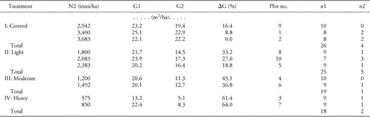

N2, postthinning stand density; G1, initial basal area; G2, postthinning basal area; ΔG, basal area removal; n1, no. of trees with detectable annual rings; n2, no. of trees with undetectable annual rings.

[figure not shown]

In winter 2006–2007, 10 trees were destructively sampled from throughout the size hierarchy in each plot (i.e., three small, four medium-sized, and three large trees from each plot), for a total of 100 sample trees. Cross-sectional discs were cut from each sample tree at a height of 1.3 m (breast height) for further laboratory analyses of past growth. Ring widths from pith to bark were analyzed for each disc, using an ITRAX X-ray microdensitometer (Cox Analytical Systems, Gothenburg, Sweden) at the University of Eastern Finland, School of Forest Sciences. For this purpose, a radial segment from pith to bark in the south direction (5 mm axially and tangentially) was first cut from each sample disc and air-dried to have a moisture content of 12%. Thereafter, the samples were scanned using the ITRAX (with standard X-ray intensity of 30 kV and 35 mA and exposure time of 20 ms), recording X-ray images with a geometrical resolution of 40 measurements per millimeter (cf. [Peltola et al. 2007](https://academic.oup.com/forestscience/article/60/4/636/4583784)). Using Density software ([Bergsten et al. 2001](https://academic.oup.com/forestscience/article/60/4/636/4583784)) and Excel macros, the X-ray images were further analyzed to create intraring density profiles for each wood specimen, and based on these profiles, ring widths from pith to bark were determined for each disc.

Out of the 100 felled trees, altogether 88 trees (7–10 trees from each plot) could be used for further data analyses ([Table 1](https://academic.oup.com/forestscience/article/60/4/636/4583784)) because 12 sample trees had annual rings that were too narrow (<0.3 mm, with <12 measuring points in each ring for ITRAX analyses). In rejected trees, the highest ring density values in particular and also the lowest ring density values were cut from the intraring density profile; thus, density profiles with sufficient quality (>20 measurements per ring needed) for reliable tree ring detection were not provided. We had a total of 18–26 sample trees from each stand density class for further data analyses ([Table 1](https://academic.oup.com/forestscience/article/60/4/636/4583784)).

### Preliminary Tests on Ring Basal Area and Tree Diameter

The annual ring width data, measured using ITRAX, represented the period from 1960 to 2005. However, we used only data after 1982, including a 4-year prethinning period (1983–1986) for estimating the tree-specific effects in growth rate and the 18-year postthinning period (1987–2005) for actual analysis of the thinning responses. The 4-year period was assumed to be sufficient to estimate the pretreatment tree-level effects on tree growth, whereas a longer prethinning period would have required a more complex model for the undisturbed growth without a significant advantage for the estimation of tree effects. The differences between thinning treatments in average pre- and postthinning ring basal areas and dbh for years 1986 and 2005 were computed and tested by using one-way analysis of variance and Tukey's tests to determine the effect of postthinning density on the average thinning responses. These analyses were done separately for smaller (dbh <85 mm) and larger (dbh ≥85 mm) trees, the dbh of 85 mm being the approximate median dbh of the data set.

### Extracting Thinning Responses Using a Multilevel Mixed-Effects Model

The age trend *f*(*T<sub>kt</sub>*) was modeled using a restricted cubic spline ([Harrell 2001](https://academic.oup.com/forestscience/article/60/4/636/4583784), [Gort et al. 2011](https://academic.oup.com/forestscience/article/60/4/636/4583784)). The spline is a smooth, flexible curve, consisting of pieces of third-order polynomials between prespecified knots *t<sub>j</sub>*, *j* = 1, …, *J*. The flexibility is controlled by the number of knots, which are placed within the range of predictor *T<sub>kt</sub>*. Using *J* knots, the spline can be expressed as

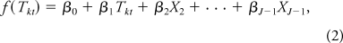

where *X<sub>j</sub>*<sub>+1</sub> is a function of tree age *T<sub>kt</sub>* and knots *t<sub>j</sub>* ([Harrell 2001](https://academic.oup.com/forestscience/article/60/4/636/4583784)) as follows

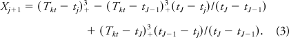

Because Equation 2 is linear with respect to its parameters β, as inserted into model 1, it yields a linear mixed-effects model that uses the transformations specified in Equation 3 as predictors.

Using a Bayesian information measure as the criterion, three knots placed at tree ages 22, 31, and 41 years were found sufficient to model the age trend. This small number of knots was sufficient because the growth of the trees from the control plots was fairly smooth within the age range of the data. The model was fitted using the *lmer* function of R package *lme4* ([R Development Core Team 2010](https://academic.oup.com/forestscience/article/60/4/636/4583784)).

### Nonlinear Mixed-Effects Modeling of Thinning Responses

The logistic curve is one of the simplest and most widely used models for S-shaped, symmetric responses. The general three-parameter logistic model (e.g., [Pinheiro and Bates 2000](https://academic.oup.com/forestscience/article/60/4/636/4583784), p. 519) allows any starting point for the reaction. We restricted the starting point to the year of thinning and reparameterized the scale parameter as the reaction time, which reduced the number of parameters to 2. However, because of the tail behavior of the logistic curve, we technically restricted the tree to already have 2% of the maximum thinning response at the year of thinning and 98% of the maximum response at the year of maximum response. However, we interpret these values as 0 and maximum responses, respectively. As a result, the thinning response *d<sub>kt</sub>* for tree *k* in year *t* was expressed using the following two-parameter nonlinear mixed-effects model

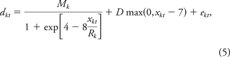

where *x<sub>kt</sub>* is the time after thinning (years), *M<sub>k</sub>* is the maximum thinning response after the reaction time *R<sub>k</sub>*, and *D* is a coefficient describing the decreasing growth trend, which is fixed to start 7 years after the thinning ([Figure 1](https://academic.oup.com/forestscience/article/60/4/636/4583784)). The selection of the fixed starting point was based on the graphs, and small changes on it had no significant effects on the results. The estimation of this effect as an additional parameter was also considered but, as one might expect, the estimation of this parameter led to convergence problems because the decreasing trend in the thinning response was so weak.

Figure 1.

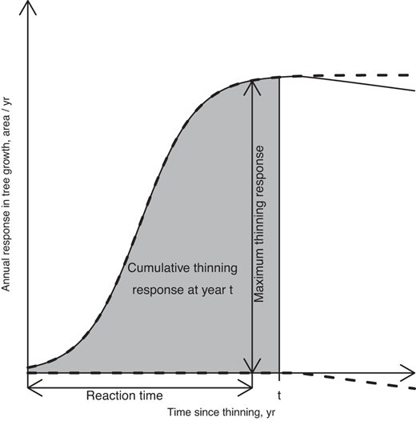

Conceptual graph of the thinning response on growth. The response (solid lines) is a sum of the two additive parts demonstrated by the dashed lines.

[figure not shown]

where δ<sub>3</sub> is the parameter and Δ is the time lag for the two observations. The motivation for proper modeling of the variance and temporal autocorrelation of the residuals arose from the resulting increase in reliability of inference based on the model, especially that of the fixed coefficients.

The model was first fitted by assuming parameters *M<sub>k</sub>* and *R<sub>k</sub>* to have fixed means and random, bivariate normal tree effects. However, part of the variation in these tree-level random effects might be explained by thinning treatments or tree diameter before thinning. To explore this potential dependency, the tree effects of both parameters were predicted, and their dependence on the thinning treatment and tree diameter were explored graphically. Whenever any potential dependence was indicated by the graphs, the predictor was incorporated into the model, and the resulting more advanced model was fitted. The Wald test, as suggested by [Pinheiro and Bates (2000)](https://academic.oup.com/forestscience/article/60/4/636/4583784), was used to iteratively test whether the more advanced model was significantly better (*P* < 0.05) than a simpler one, until no improvement was possible.

## Results

### Dbh before thinning and 18 years after thinning and average ring basal area before and after thinning.

Table 2.

Dbh before thinning and 18 years after thinning and average ring basal area before and after thinning.

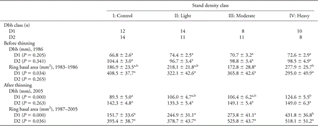

Data are means ± SE. *P* values indicate the result of an one-way analysis of variance, and the letters indicate a grouping resulting from a Tukey test on the difference between stand density classes (SD I–IV) for each diameter class (D1, 45.0–84.9 mm; D2, 85.0–125.0 mm) (*P* < 0.05).

[figure not shown]